# Spatial LR co-expression with stLearn (one section)

- Show All Code
- Hide All Code

Same question as `09`, with stLearn’s CCI method (Pham et al., *Nat Commun* 2023) instead of bivariate Moran’s I, run per cell (each cell = one “spot”):

1. **LR score per cell:** ligand in the cell and receptor in its neighbours within `RADIUS` (and the reverse).
2. **Significance per cell:** compared with random gene pairs whose expression matches the ligand and receptor (`N_PAIRS` per LR pair), then FDR-corrected across the LR pairs tested in that cell.
3. **Cell-type interactions:** for cells with a significant score, which cell-type pairs (cell ↔︎ neighbour) are over-represented, by permuting cell-type labels.

LR pairs: our panel-covered pairs from `08` plus the mouse connectomeDB2020 (literature) pairs on the panel, used as a background. Input: `output/08_STARmapPLUS_CCC_GenePanelCheck/starmap_hpc_export/`. One section (default `13months_replicate_1`, as in `09`); `10b` runs all 4.

## 1 Imports

```python
import inspect
import os

import numpy as np
import pandas as pd
import scipy.io as sio
import anndata as ad
import matplotlib.pyplot as plt
from scipy.spatial import cKDTree
from scipy.stats import norm
import stlearn as st

print("stLearn version:", st.__version__)
```

```
stLearn version: 1.4.1
```

## 2 Settings

```python
export_dir = "output/08_STARmapPLUS_CCC_GenePanelCheck/starmap_hpc_export"   # written by 08_STARmapPLUS_CCC_GenePanelCheck.qmd
out_dir    = "output/09b_STARmapPLUS_stlearn"
os.makedirs(out_dir, exist_ok=True)

SECTION      = "13months_replicate_1"   # same section as 09
CELLTYPE_COL = "celltype_merged"        # SMC + Endo merged to Vascular in 08
RADIUS       = 400     # neighbourhood radius, same coordinate units and scale as 09's bandwidth
N_PAIRS      = 1000    # random gene pairs per LR pair for the per-cell background
MIN_SPOTS    = 10      # an LR pair needs a score in more than this many cells to be tested
N_PERMS_CCI  = 100     # cell-type label permutations for the cell-type interaction test
N_CPUS       = None    # None = all cores
SEED         = 1337
LR_DATABASES = ["connectomeDB2020_lit"]
```

## 3 Helper functions

```python
def build_section_adata(expr, genes, cells, meta, coords, celltype_col):
    """AnnData for stLearn: log-normalized expression, cell coordinates as imagecol (x) /
    imagerow (y). stLearn only needs these two obs columns when `distance` is given."""
    a = ad.AnnData(X=expr, obs=meta.copy(), var=pd.DataFrame(index=genes))
    a.obs_names = cells
    a.var_names_make_unique()
    # stLearn splits "L_R" strings on "_", so gene names must not contain "_"
    a.var_names = [g.replace("_", "-") for g in a.var_names]
    a.obs["imagecol"] = coords["spatial_1"].to_numpy()
    a.obs["imagerow"] = coords["spatial_2"].to_numpy()
    a.obsm["spatial"] = coords[["spatial_1", "spatial_2"]].to_numpy()
    # plain Python strings (object dtype, not categorical/pandas string): stLearn's numba code needs them
    a.obs[celltype_col] = a.obs[celltype_col].astype(str).replace("nan", "Unknown").astype(object)
    return a


def call_with_supported(fn, **kwargs):
    """Pass only the arguments this stLearn version accepts (e.g. random_state is not in older versions)."""
    accepted = inspect.signature(fn).parameters
    return fn(**{k: v for k, v in kwargs.items() if k in accepted})


def run_stlearn_lr(a, lrs, radius, n_pairs, min_spots, n_cpus, seed, verbose=True):
    """stLearn LR test per cell: LR score from ligand in a cell and receptor in its neighbours
    within `radius` (and the reverse); p-values from random gene pairs with matched expression.
    p-values are then FDR-corrected across the LR pairs tested in each cell (correct_axis='spot')."""
    call_with_supported(st.tl.cci.run, adata=a, lrs=lrs, min_spots=min_spots, distance=radius,
                        n_pairs=n_pairs, n_cpus=n_cpus, random_state=seed, verbose=verbose)
    if "lr_summary" not in a.uns:
        raise RuntimeError("stLearn returned no valid LR pairs -- lower MIN_SPOTS or increase RADIUS.")
    st.tl.cci.adj_pvals(a, correct_axis="spot", pval_adj_cutoff=0.05, adj_method="fdr_bh")
    summ = a.uns["lr_summary"].copy()
    summ.index.name = "lr"
    summ = summ.reset_index()
    summ["ligand"] = summ["lr"].str.split("_").str[0]
    summ["receptor"] = summ["lr"].str.split("_").str[1]
    summ["n_cells"] = a.n_obs
    summ["frac_sig"] = summ["n_spots_sig"] / a.n_obs          # share of cells with a significant LR score
    summ["frac_scored"] = summ["n_spots"] / a.n_obs           # share of cells with any LR score
    return summ


def detection_matched_p(summ, detection, our_lrs, k=50):
    """For each of our pairs: compare its frac_sig with the k database pairs whose ligand and
    receptor detection rates are closest (log10 space). One-sided empirical p (ours higher)."""
    db = summ[~summ["lr"].isin(our_lrs)].copy()
    eps = 1e-4
    def det_xy(df):
        return np.column_stack([np.log10(detection.reindex(df["ligand"]).to_numpy() + eps),
                                np.log10(detection.reindex(df["receptor"]).to_numpy() + eps)])
    tree = cKDTree(det_xy(db))
    rows = []
    for _, r in summ[summ["lr"].isin(our_lrs)].iterrows():
        kk = min(k, len(db))
        _, idx = tree.query(det_xy(pd.DataFrame([r]))[0], k=kk)
        null = db["frac_sig"].to_numpy()[np.atleast_1d(idx)]
        rows.append({"lr": r["lr"], "frac_sig": r["frac_sig"], "n_matched": kk,
                     "matched_median": float(np.median(null)),
                     "p_matched": (1 + np.sum(null >= r["frac_sig"])) / (kk + 1)})
    return pd.DataFrame(rows)


def run_celltype_cci(a, lrs_subset, celltype_col, n_perms, min_spots, n_cpus, seed, verbose=True):
    """stLearn cell-type CCI for a subset of LR pairs. The result matrices are subset to these
    pairs first (columns of the obsm matrices follow the lr_summary row order), so the label
    permutations are only run for the pairs of interest."""
    b = a.copy()
    summ = b.uns["lr_summary"]
    keep = np.where(summ.index.isin(lrs_subset))[0]
    b.uns["lr_summary"] = summ.iloc[keep].copy()
    for key in ["lr_scores", "lr_sig_scores", "p_vals", "p_adjs", "-log10(p_adjs)"]:
        if key in b.obsm:
            b.obsm[key] = np.asarray(b.obsm[key])[:, keep]
    # n_cpus=1: stLearn's label permutations run in parallel threads, each with its own random
    # stream, so p-values change between runs unless they run on a single thread
    call_with_supported(st.tl.cci.run_cci, adata=b, use_label=celltype_col, spot_mixtures=False,
                        min_spots=min_spots, sig_spots=True, n_perms=n_perms, n_cpus=1,
                        random_state=seed, verbose=verbose)
    raw = b.uns.get(f"per_lr_cci_raw_{celltype_col}", {})
    pvals = b.uns.get(f"per_lr_cci_pvals_{celltype_col}", {})
    long = []
    for lr, mat in raw.items():
        m = mat.stack().rename("n_interactions").reset_index()
        m.columns = ["celltype_sig_cell", "celltype_neighbour", "n_interactions"]
        pv = pvals[lr].stack().reset_index(drop=True)
        m["p_value"] = pv.to_numpy()
        m["lr"] = lr
        long.append(m)
    return pd.concat(long, ignore_index=True) if long else pd.DataFrame(
        columns=["celltype_sig_cell", "celltype_neighbour", "n_interactions", "p_value", "lr"])


def lr_label(lr):
    return lr.replace("_", " -> ")
```

## 4 Load the export and select the section

```python
expr  = sio.mmread(f"{export_dir}/expr_norm.mtx").tocsr().T   # genes x cells -> cells x genes
genes = pd.read_csv(f"{export_dir}/genes.txt", header=None)[0].astype(str).tolist()
cells = pd.read_csv(f"{export_dir}/cells.txt", header=None)[0].astype(str).tolist()
coords = pd.read_csv(f"{export_dir}/coordinates.csv").set_index("cell_id").loc[cells]
meta   = pd.read_csv(f"{export_dir}/metadata.csv").set_index("cell_id").loc[cells]

keep = (meta["section_id"] == SECTION).to_numpy()
if keep.sum() == 0:
    raise RuntimeError(f"No cells for section {SECTION}; available: {sorted(meta['section_id'].unique())}")

adata = build_section_adata(expr[keep], genes, [c for c, k in zip(cells, keep) if k],
                            meta.loc[keep], coords.loc[keep], CELLTYPE_COL)
adata
```

```
AnnData object with n_obs × n_vars = 3901 × 2766
    obs: 'orig.ident', 'nCount_RNA', 'nFeature_RNA', 'NAME', 'biosample_id', 'donor_id', 'species', 'species__ontology_label', 'sex', 'disease', 'disease__ontology_label', 'organ', 'organ__ontology_label', 'library_preparation_protocol', 'library_preparation_protocol__ontology_label', 'orig_index', …
    obsm: 'spatial'
    layers: None (.X)
```

## 5 LR pairs

Our pairs (`lr_pairs.csv` from `08`) plus the database pairs whose genes are both on the panel.

```python
ours_df = pd.read_csv(f"{export_dir}/lr_pairs.csv")
our_lrs = sorted({f"{l.replace('_', '-')}_{r.replace('_', '-')}"
                  for l, r in zip(ours_df["ligand_complex"], ours_df["receptor_complex"])})

db_lrs = np.asarray(st.tl.cci.load_lrs(LR_DATABASES, species="mouse"))
panel = set(adata.var_names)
db_on_panel = sorted({lr for lr in db_lrs if all(g in panel for g in lr.split("_"))})

lrs = np.array(sorted(set(db_on_panel) | set(our_lrs)))
print(f"Our pairs: {len(our_lrs)} ({len(set(our_lrs) & set(db_lrs))} of them also in {LR_DATABASES})")
print(f"Database pairs on the panel: {len(db_on_panel)} | total tested: {len(lrs)}")
```

```
Our pairs: 13 (7 of them also in ['connectomeDB2020_lit'])
Database pairs on the panel: 427 | total tested: 433
```

## 6 Neighbourhood size

Number of other cells within `RADIUS` of each cell. stLearn sums over these neighbours, so very small neighbourhoods give little signal and very large ones dilute it.

```
RADIUS = 400: median 22 neighbours, 0.7% of cells with none
```

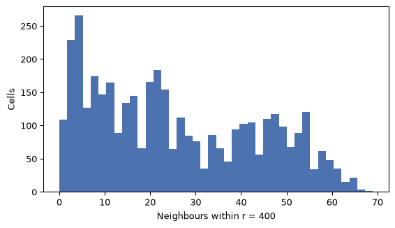

```python
xy = adata.obs[["imagerow", "imagecol"]].to_numpy()
n_neigh = np.array([len(n) - 1 for n in cKDTree(xy).query_ball_point(xy, RADIUS)])
print(f"RADIUS = {RADIUS}: median {np.median(n_neigh):.0f} neighbours, "
      f"{(n_neigh == 0).mean():.1%} of cells with none")

fig, ax = plt.subplots(figsize=(6, 3.5))
ax.hist(n_neigh, bins=40, color="#4c72b0")
ax.set_xlabel(f"Neighbours within r = {RADIUS}")
ax.set_ylabel("Cells")
plt.tight_layout()
plt.show()
```

## 7 Run the stLearn LR test

```python
summary = run_stlearn_lr(adata, lrs, RADIUS, N_PAIRS, MIN_SPOTS, N_CPUS, SEED)
summary["is_ours"] = summary["lr"].isin(our_lrs)

missing = sorted(set(our_lrs) - set(summary["lr"]))
if missing:
    print(f"Not tested (scored in <= {MIN_SPOTS} cells or genes missing): {missing}")
summary.head(10)
```

```
Calculating neighbours...
28 spots with no neighbours, 22 median spot neighbours.
Spot neighbour indices stored in adata.obsm['spot_neighbours'] & adata.obsm['spot_neigh_bcs'].
Altogether 418 valid L-R pairs
```

```
Storing results:

lr_scores stored in adata.obsm['lr_scores'].
p_vals stored in adata.obsm['p_vals'].
p_adjs stored in adata.obsm['p_adjs'].
-log10(p_adjs) stored in adata.obsm['-log10(p_adjs)'].
lr_sig_scores stored in adata.obsm['lr_sig_scores'].

Per-spot results in adata.obsm have columns in same order as rows in adata.uns['lr_summary'].
Summary of LR results in adata.uns['lr_summary'].
Updated adata.uns[lr_summary]
Updated adata.obsm[lr_scores]
Updated adata.obsm[lr_sig_scores]
Updated adata.obsm[p_vals]
Updated adata.obsm[p_adjs]
Updated adata.obsm[-log10(p_adjs)]
Not tested (scored in <= 10 cells or genes missing): ['Efnb2_Grm5']
```

|  | lr | n_spots | n_spots_sig | n_spots_sig_pval | ligand | receptor | n_cells | frac_sig | frac_scored | is_ours |
| --- | --- | --- | --- | --- | --- | --- | --- | --- | --- | --- |
| 0 | Cadm3_Cadm3 | 879 | 318 | 715 | Cadm3 | Cadm3 | 3901 | 0.081518 | 0.225327 | False |
| 1 | Agrn_Atp1a3 | 2025 | 210 | 554 | Agrn | Atp1a3 | 3901 | 0.053832 | 0.519098 | False |
| 2 | Cadm1_Cadm1 | 634 | 195 | 458 | Cadm1 | Cadm1 | 3901 | 0.049987 | 0.162522 | False |
| 3 | App_Aplp1 | 2883 | 193 | 571 | App | Aplp1 | 3901 | 0.049474 | 0.739041 | True |
| 4 | Vegfa_Flt1 | 635 | 159 | 258 | Vegfa | Flt1 | 3901 | 0.040759 | 0.162779 | False |
| 5 | Bsg_Sele | 1599 | 158 | 271 | Bsg | Sele | 3901 | 0.040502 | 0.409895 | False |
| 6 | Cxcl12_Itgb1 | 636 | 133 | 246 | Cxcl12 | Itgb1 | 3901 | 0.034094 | 0.163035 | True |
| 7 | Fga_Itgb1 | 721 | 132 | 217 | Fga | Itgb1 | 3901 | 0.033837 | 0.184824 | False |
| 8 | Apoe_Lrp2 | 640 | 129 | 228 | Apoe | Lrp2 | 3901 | 0.033068 | 0.164060 | False |
| 9 | Calm1_Ptpra | 2277 | 123 | 334 | Calm1 | Ptpra | 3901 | 0.031530 | 0.583696 | True |

## 8 Our pairs vs the database pairs

`frac_sig` = share of cells where the LR score is significant (FDR < 0.05). Our pairs are shown against all database pairs tested in this section.

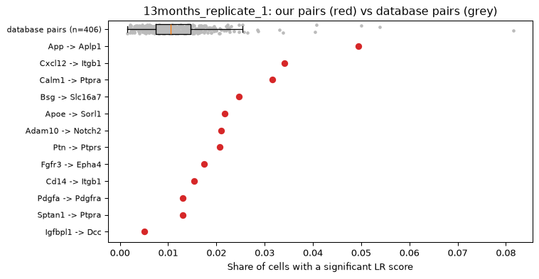

|  | lr | n_spots | n_spots_sig | frac_scored | frac_sig | percentile_vs_db |
| --- | --- | --- | --- | --- | --- | --- |
| 3 | App_Aplp1 | 2883 | 193 | 0.739041 | 0.049474 | 99.261084 |
| 6 | Cxcl12_Itgb1 | 636 | 133 | 0.163035 | 0.034094 | 98.768473 |
| 9 | Calm1_Ptpra | 2277 | 123 | 0.583696 | 0.031530 | 98.275862 |
| 16 | Bsg_Slc16a7 | 1050 | 96 | 0.269162 | 0.024609 | 96.551724 |
| 27 | Apoe_Sorl1 | 333 | 85 | 0.085363 | 0.021789 | 94.334975 |
| 30 | Adam10_Notch2 | 419 | 82 | 0.107408 | 0.021020 | 93.842365 |
| 33 | Ptn_Ptprs | 639 | 81 | 0.163804 | 0.020764 | 93.349754 |
| 61 | Fgfr3_Epha4 | 531 | 68 | 0.136119 | 0.017431 | 86.699507 |
| 99 | Cd14_Itgb1 | 258 | 60 | 0.066137 | 0.015381 | 77.339901 |
| 150 | Pdgfa_Pdgfra | 235 | 51 | 0.060241 | 0.013074 | 64.532020 |
| 153 | Sptan1_Ptpra | 487 | 51 | 0.124840 | 0.013074 | 64.532020 |
| 365 | Igfbpl1_Dcc | 40 | 20 | 0.010254 | 0.005127 | 11.822660 |

```python
ours_summary = summary[summary["is_ours"]].copy()
db_vals = summary.loc[~summary["is_ours"], "frac_sig"].to_numpy()
ours_summary["percentile_vs_db"] = [100 * np.mean(db_vals < v) for v in ours_summary["frac_sig"]]
ours_summary = ours_summary.sort_values("frac_sig", ascending=False)

fig, ax = plt.subplots(figsize=(8, max(4, 0.35 * len(ours_summary))))
ax.boxplot(db_vals, vert=False, positions=[-1], widths=0.6, showfliers=False)
ax.scatter(db_vals, np.full(len(db_vals), -1) + np.random.default_rng(0).uniform(-0.25, 0.25, len(db_vals)),
           s=6, color="#bbbbbb", zorder=1)
ax.scatter(ours_summary["frac_sig"], range(len(ours_summary)), color="#d62728", zorder=3)
ax.set_yticks([-1] + list(range(len(ours_summary))))
ax.set_yticklabels([f"database pairs (n={len(db_vals)})"] + [lr_label(l) for l in ours_summary["lr"]], fontsize=8)
ax.invert_yaxis()
ax.set_xlabel("Share of cells with a significant LR score")
ax.set_title(f"{SECTION}: our pairs (red) vs database pairs (grey)")
plt.tight_layout()
plt.show()

ours_summary[["lr", "n_spots", "n_spots_sig", "frac_scored", "frac_sig", "percentile_vs_db"]]
```

## 9 Detection-matched comparison

Highly detected genes reach significance in more cells. Each of our pairs is compared with the 50 database pairs whose ligand and receptor detection rates are closest; `p_matched` is one-sided (ours higher).

```python
X = adata.X
detection = pd.Series(np.asarray((X > 0).mean(axis=0)).ravel(), index=adata.var_names)

matched = detection_matched_p(summary, detection, our_lrs, k=50)
matched = matched.sort_values("p_matched")
matched
```

|  | lr | frac_sig | n_matched | matched_median | p_matched |
| --- | --- | --- | --- | --- | --- |
| 1 | Cxcl12_Itgb1 | 0.034094 | 50 | 0.016662 | 0.058824 |
| 0 | App_Aplp1 | 0.049474 | 50 | 0.018841 | 0.078431 |
| 3 | Bsg_Slc16a7 | 0.024609 | 50 | 0.016022 | 0.117647 |
| 4 | Apoe_Sorl1 | 0.021789 | 50 | 0.015124 | 0.117647 |
| 2 | Calm1_Ptpra | 0.031530 | 50 | 0.018457 | 0.137255 |
| 5 | Adam10_Notch2 | 0.021020 | 50 | 0.014868 | 0.137255 |
| 6 | Ptn_Ptprs | 0.020764 | 50 | 0.016406 | 0.176471 |
| 7 | Fgfr3_Epha4 | 0.017431 | 50 | 0.015893 | 0.352941 |
| 8 | Cd14_Itgb1 | 0.015381 | 50 | 0.014355 | 0.411765 |
| 9 | Pdgfa_Pdgfra | 0.013074 | 50 | 0.013843 | 0.666667 |
| 10 | Sptan1_Ptpra | 0.013074 | 50 | 0.015252 | 0.823529 |
| 11 | Igfbpl1_Dcc | 0.005127 | 50 | 0.007049 | 0.823529 |

## 10 Where the LR scores are significant

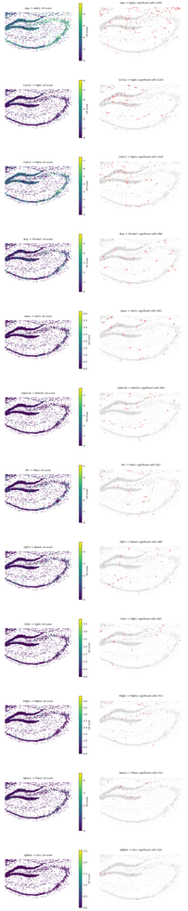

```python
plot_lrs = [lr for lr in ours_summary["lr"] if lr in list(adata.uns["lr_summary"].index)]
lr_order = list(adata.uns["lr_summary"].index)
xy_plot = adata.obsm["spatial"]

fig, axes = plt.subplots(len(plot_lrs), 2, figsize=(11, 4.5 * len(plot_lrs)), squeeze=False)
for i, lr in enumerate(plot_lrs):
    j = lr_order.index(lr)
    score = np.asarray(adata.obsm["lr_scores"])[:, j]
    sig = np.asarray(adata.obsm["lr_sig_scores"])[:, j] > 0
    ax = axes[i][0]
    pts = ax.scatter(xy_plot[:, 0], xy_plot[:, 1], c=score, cmap="viridis", s=4, edgecolors="none")
    plt.colorbar(pts, ax=ax, shrink=0.7, label="LR score")
    ax.set_title(f"{lr_label(lr)}: LR score", fontsize=10)
    ax = axes[i][1]
    ax.scatter(xy_plot[:, 0], xy_plot[:, 1], color="lightgrey", s=3, edgecolors="none")
    ax.scatter(xy_plot[sig, 0], xy_plot[sig, 1], color="#d62728", s=6, edgecolors="none")
    ax.set_title(f"{lr_label(lr)}: significant cells ({sig.sum()})", fontsize=10)
    for ax in axes[i]:
        ax.set_aspect("equal"); ax.invert_yaxis(); ax.axis("off")
plt.tight_layout()
plt.show()
```

## 11 Cell-type interactions

For each of our pairs, the numbers are **cell–neighbour pairs**, not cells: a significant cell (row type) and one of its neighbours within `RADIUS` (column type), with the ligand in one and the receptor in the other (either direction). The neighbour itself does not need to be significant, so one significant cell can contribute many pairs; in dense regions (DG, CA1) the counts can be much larger than the number of significant cells, shown in each panel title. `*` = more pairs than expected from shuffled cell-type labels (p < 0.05).

```
Getting cached neighbourhood information...
Getting information for CCI counting...
```

```
Significant counts of cci_rank interactions for all LR pairs in data.uns[lr_cci_celltype_merged]
Significant counts of cci_rank interactions for each LR pair stored in dictionary data.uns[per_lr_cci_celltype_merged]
Cell-type CCI computed for 12 pair(s) with > 3 significant cells
```

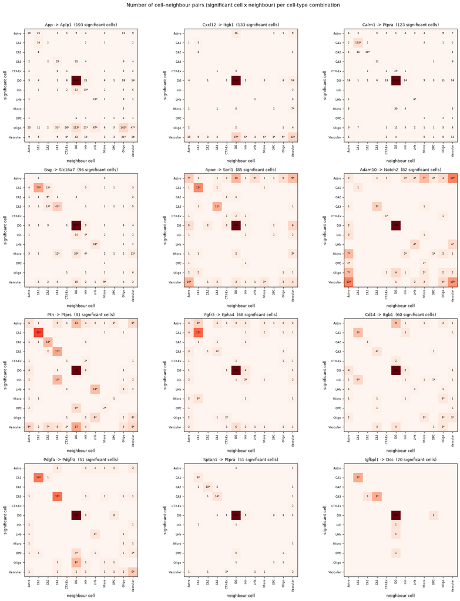

```python
cci_long = run_celltype_cci(adata, plot_lrs, CELLTYPE_COL, N_PERMS_CCI, min_spots=3,
                            n_cpus=N_CPUS, seed=SEED)
cci_lrs = list(dict.fromkeys(cci_long["lr"]))
print(f"Cell-type CCI computed for {len(cci_lrs)} pair(s) with > 3 significant cells")

ncol = 3
nrow = int(np.ceil(len(cci_lrs) / ncol)) if cci_lrs else 0
if nrow:
    fig, axes = plt.subplots(nrow, ncol, figsize=(5.5 * ncol, 5 * nrow), squeeze=False)
    for ax, lr in zip(axes.ravel(), cci_lrs):
        sub = cci_long[cci_long["lr"] == lr]
        mat = sub.pivot(index="celltype_sig_cell", columns="celltype_neighbour", values="n_interactions")
        pv  = sub.pivot(index="celltype_sig_cell", columns="celltype_neighbour", values="p_value").loc[mat.index, mat.columns]
        im = ax.imshow(mat.to_numpy(), cmap="Reds")
        for (r, c), v in np.ndenumerate(mat.to_numpy()):
            if v > 0:
                ax.text(c, r, f"{v}{'*' if pv.iat[r, c] < 0.05 else ''}", ha="center", va="center", fontsize=6)
        ax.set_xticks(range(mat.shape[1])); ax.set_xticklabels(mat.columns, rotation=90, fontsize=7)
        ax.set_yticks(range(mat.shape[0])); ax.set_yticklabels(mat.index, fontsize=7)
        ax.set_xlabel("neighbour cell"); ax.set_ylabel("significant cell")
        n_sig = int(summary.loc[summary["lr"] == lr, "n_spots_sig"].iloc[0])
        ax.set_title(f"{lr_label(lr)}  ({n_sig} significant cells)", fontsize=10)
    for ax in axes.ravel()[len(cci_lrs):]:
        ax.axis("off")
    plt.suptitle("Number of cell–neighbour pairs (significant cell x neighbour) per cell-type combination", y=1.01)
    plt.tight_layout()
    plt.show()
```

## 12 Save results

```python
summary.to_csv(f"{out_dir}/stlearn_lr_summary.csv", index=False)
ours_summary.merge(matched[["lr", "matched_median", "p_matched"]], on="lr", how="left") \
    .to_csv(f"{out_dir}/stlearn_our_pairs.csv", index=False)
cci_long.to_csv(f"{out_dir}/stlearn_celltype_cci_our_pairs.csv", index=False)
print("Saved to", out_dir)
```

```
Saved to output/09b_STARmapPLUS_stlearn
```

## 13 Notes

- Unlike liana’s Moran’s I p-value (shuffled expression), stLearn’s per-cell p-value already compares each LR pair with random gene pairs of similar expression, so it partly controls for “both genes are just expressed in the same region”.
- `frac_sig` depends on detection; use `p_matched` (vs database pairs with similar detection) when comparing pairs.
- Cell-type interactions are undirected: a row/column entry counts ligand-in-one/receptor-in-the-other in either direction.
- `RADIUS` is in coordinate units; 400 matches the Moran’s I bandwidth in `09`/`10`.